# Inference about Simple Regression

b06208001 龔泓愷

2018年12月14日

## Q1416

1. `yhat = 98.6 - 0.0138(age)`  
   The predicted body temperature for someone who is 21 years old is *98.3102*.

```r
fit21 = 98.6 - 0.0138 * 21; fit21
```

```
## [1] 98.3102
```

```r
98.3 - fit21
```

```
## [1] -0.0102
```

```r
98.4 - fit21
```

```
## [1] 0.0898
```

3. The Interval is **(96.92107, 99.69933)**

```r
t = qt(0.975, df = 98);t
```

```
## [1] 1.984467
```

```r
c(fit21 - t * 0.7, fit21 + t * 0.7)
```

```
## [1] 96.92107 99.69933
```

4. NO.  
   It would not be unusual since the value is contained in the interval we’ve calculated above.

## Q1428

1. Since the regression line is derived from the sample, the best notation for the slope would be `b1`.
2. The 95% confidence interval for beta1 is **(-0.022134, -0.005465)**  
   which means that we are 95% confident that the true value of the slope of the population regression line is contained in the interval.

```r
c(-0.0138 - t * 0.0042, -0.0138 + t * 0.0042)
```

```
## [1] -0.022134763 -0.005465237
```

3. The interval is **(-0.22, -0.05)**.

## Q1436

1. Regression Equation: `Y = 34.98 + 10.66X`  
   yhat is the number shown in the column labeled ‘Fit’.

```r
Fit = 34.98 + 10.66 * 4; Fit
```

```
## [1] 77.62
```

2. 95%CI = (76.670, 78.571)  
   We can say that we are of 95% confidence that the *mean* value of `TIMENEXT` for a population of individuals who all have the same particular value of `DURATION` will falls beween `76.670` and `78.571`.
3. 95%PI = (64.307, 90.934)  
   We can say that we are of 95% confidence tha the value of `TIMENEXT` for an individual with a particular value of `DURATION` will falls beween `64.307` and `90.934`.
4. Prediction Interval for y  
   Because we want to know the expected time to see the next eruption of the specific geyser rather than the mean value of all geysers whose previous eruption lasted that long.

## Q1454

1. `yhat = 30 + 0.576x`
2. According to the Minitab output, t = `7.73`.

```r
b1 = 0.57568; se.b1 = 0.07445
t = (0.57568 - 0)/0.07445; t
```

```
## [1] 7.732438
```

3. **Step1**  
   H0：beta1 = 0，兩者非線性相關  
   Ha：beta1 != 0，兩者為線性相關  
   **Step2**  
   `b1 = 0.57568; t =7.73`  
   **Step3**  
   The reported p-value is 0.000.  
   **Step4** Since the p-value is less than any significance level we might use,  
   We can rehect the null hypothesis in favor of the alternative hypothesis.  
   **Step5**  
   We can conclude that there is a linear relationship between a college man’s height and his father’s height.
4. n = 76 with 3 missing values >> df = 73 - 2 = 71.

```r
t = qt(1 - 0.05/2, df = 71);t#calculating t*
```

```
## [1] 1.993943
```

```r
c(b1 - t * se.b1, b1 + t * se.b1)
```

```
## [1] 0.4272309 0.7241291
```

The 95% confidence interval for beta1 is **0.4272309 0.7241291**  
which means that we are 95% confident that the true value of the slope of the population regression line is contained in the interval.  
According to this interval,  
we could say that we are 95% certain that an increase in father’s height by 1 inch causes an increase in his son’s height by 0.4273 to 0.7241 inches.

## Q1456

```r
fit65 = 29.981 + 0.57568*65; fit65
```

```
## [1] 67.4002
```

## R Function Practice

```r
data <- read.csv("Vehicles.csv")
data = na.omit(data)
head(data, 5)
```

```
##   Year Vehicle  GDP
## 1 1992 2907022 5615
## 2 1993 3238754 6205
## 3 1994 3570497 6784
## 4 1995 3874203 7397
## 5 1996 4146475 8037
```

#### **1. 估計簡單回歸式**

```r
Vehicle = data$Vehicle
GDP = data$GDP
RESULTS <- lm(Vehicle ~ GDP)
summary(RESULTS)
```

```
##
## Call:
## lm(formula = Vehicle ~ GDP)
##
## Residuals:
##     Min      1Q  Median      3Q     Max
## -413891 -113513    3883  119749  334703
##
## Coefficients:
##              Estimate Std. Error t value Pr(>|t|)
## (Intercept) 1.606e+06  1.251e+05   12.84 3.06e-12 ***
## GDP         3.055e+02  1.022e+01   29.89  < 2e-16 ***
## ---
## Signif. codes:  0 '***' 0.001 '**' 0.01 '*' 0.05 '.' 0.1 ' ' 1
##
## Residual standard error: 175800 on 24 degrees of freedom
## Multiple R-squared:  0.9738, Adjusted R-squared:  0.9727
## F-statistic: 893.2 on 1 and 24 DF,  p-value: < 2.2e-16
```

```r
anova(RESULTS)
```

```
## Analysis of Variance Table
##
## Response: Vehicle
##           Df     Sum Sq    Mean Sq F value    Pr(>F)
## GDP        1 2.7609e+13 2.7609e+13   893.2 < 2.2e-16 ***
## Residuals 24 7.4185e+11 3.0910e+10
## ---
## Signif. codes:  0 '***' 0.001 '**' 0.01 '*' 0.05 '.' 0.1 ' ' 1
```

##### 1.1. 以五步驟進行假說檢定

假設顯著水準alpha = 0.05  
**Step 1**  
H0：beta1 = 0，兩者非線性相關  
Ha：beta1 != 0，兩者為線性相關

**Step 2**  
b1 = 3.055e+02  
t_value = 29.89

**Step3**  
p_value = < 2.2e-16

**Step4**  
p_value < 0.05，Reject H0

**Step5**  
根據假說檢定，我們能下 beta1 != 0，也就是兩者為線性相關的結論。

##### 1.2. 計算斜率的信賴區間

```r
n = nrow(data)
#Manual Calculation
x.mean = mean(GDP)
y.mean = mean(Vehicle)

data$xx = GDP - x.mean
data$yy = Vehicle - y.mean
data$xxyy = data$xx * data$yy
data$xx2 = data$xx ^ 2

#b1
b1 = sum(data$xxyy)/sum(data$xx2);b1
```

```
## [1] 305.5035
```

```r
#SSE SSR
yhat = RESULTS$fitted.values
SSE = sum((Vehicle - yhat) ^ 2)
SSR = sum((yhat - y.mean) ^ 2)

#Standard error of regression
s = sqrt(SSE/(n - 2));s
```

```
## [1] 175813.1
```

```r
#Standard error of b1
se.b1 = s/sqrt(sum(data$xx2));se.b1
```

```
## [1] 10.22215
```

```r
#Confidence interval for b1
alpha = 0.05
t = qt(1 - alpha/2, df = n - 2)#calculating t*
CI.b1 = c(b1 - t * se.b1, b1 + t * se.b1);CI.b1
```

```
## [1] 284.406 326.601
```

斜率(b1)95%信心水準下的信賴區間為**(284.406, 326.601)**

#### **2. 估計GDP = c(9000, 13000, 17000)之PI與CI**

##### 2.1. 計算PI與CI

```r
#PI
PI = predict(RESULTS, data.frame(GDP = c(9000, 13000, 17000)), interval = "prediction", level = 0.95);PI
```

```
##       fit     lwr     upr
## 1 4355042 3980710 4729374
## 2 5577056 5206360 5947752
## 3 6799070 6413130 7185010
```

```r
#CI
CI = predict(RESULTS, data.frame(GDP = c(9000, 13000, 17000)), interval = "confidence", level = 0.95);CI
```

```
##       fit     lwr     upr
## 1 4355042 4263081 4447003
## 2 5577056 5501243 5652869
## 3 6799070 6667609 6930530
```

##### 2.2. 解釋其代表意義

**Prediction Interval**  
該區間意指，擁有相同解釋變項(x)的每個個體其反應變項(y)會落在相對應預測區間的機率為0.95。

當GDP為9000時，汽車數量(Vehicle)會落在3980710與4729374之間的機率為0.95。  
當GDP為13000時，汽車數量(Vehicle)會落在5206360與5947752之間的機率為0.95。  
當GDP為17000時，汽車數量(Vehicle)會落在6413130與7185010之間的機率為0.95。

**Confidence Interval**  
該區指意指，我們有95%的信心水準能說對於所有擁有相同解釋變項(x)其反應變項(y)的平均值會落在相對應信賴區間，也就是期望值的區間。

##### 2.3. 繪製PI與CI區間圖

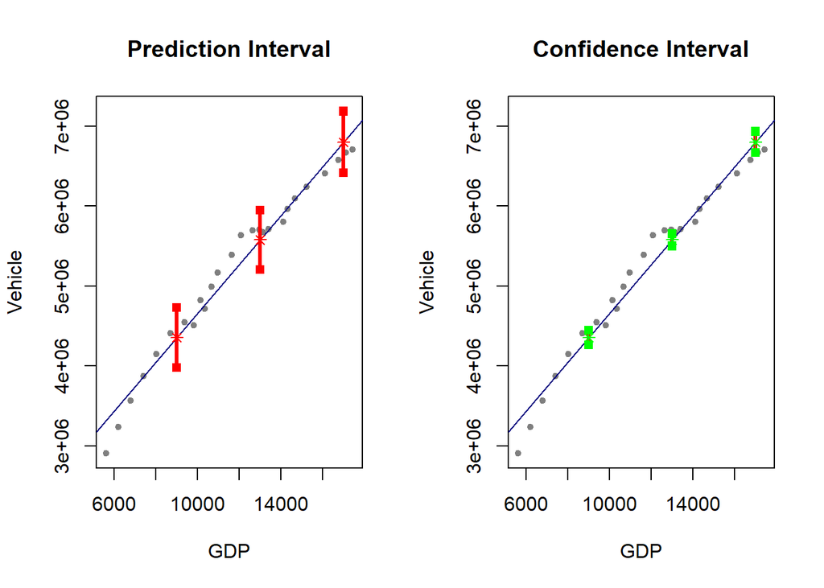

```r
fit = PI[,1]
PI.low = PI[,2]
PI.up = PI[,3]
CI.low = CI[,2]
CI.up = CI[,3]

xx.test =  c(9000, 13000, 17000)

#Plot for PI & CI
#Spilt the plot
par(mfrow = c(1, 2))
#plot PI
plot(GDP, Vehicle, pch = 20, col = 'gray50',
     main = 'Prediction Interval', xlab = 'GDP', ylab = 'Vehicle',
     ylim = c(2900000, 7200000))
abline(RESULTS, col = 'navy')#regression line
for (i in 1:length(xx.test)) {
  lines(c(xx.test[i], xx.test[i]), c(PI.low[i], PI.up[i]), col = 'Red', lwd = 3)
  points(xx.test[i], PI.low[i], col = 'red', pch = 15)#lower point
  points(xx.test[i], PI.up[i], col = 'red', pch = 15)#upper point
  points(xx.test[i], fit[i], col = 'red', pch = 8)#estimated value
}
#plot CI
plot(GDP, Vehicle, pch = 20, col = 'gray50',
     main = 'Confidence Interval', xlab = 'GDP', ylab = 'Vehicle',
     ylim = c(2900000, 7200000))
abline(RESULTS, col = 'navy')#regression line
for (i in 1:length(xx.test)) {
  lines(c(xx.test[i], xx.test[i]), c(CI.low[i], CI.up[i]), col = 'Red', lwd = 3)
  points(xx.test[i], CI.low[i], col = 'green', pch = 15)#lower point
  points(xx.test[i], CI.up[i], col = 'green', pch = 15)#upper point
  points(xx.test[i], fit[i], col = 'green', pch = 8)#estimated value
}
```

#### **3. 進行回歸診斷與處理**

##### 3.1. 逐條診斷與解釋

**Scatterplot**

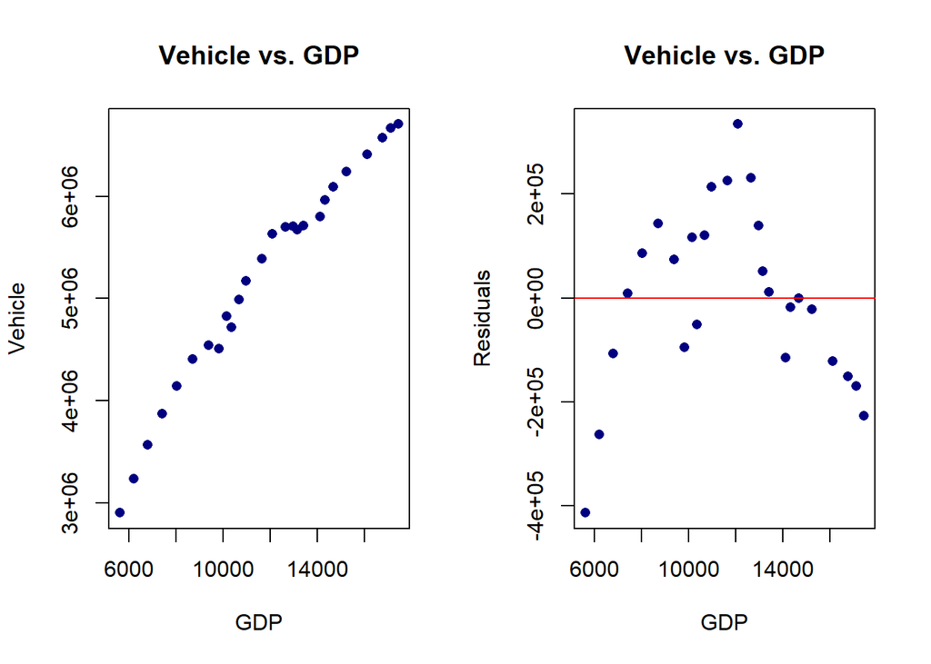

```r
par(mfrow = c(1, 2))
#Scatterplot of y vs. x
plot(GDP, Vehicle, pch = 16, cex = 1, col = 'navy',
     main = 'Vehicle vs. GDP', xlab = 'GDP', ylab = 'Vehicle')
#Scatterplot of residuals vs. x
res = Vehicle - yhat
plot(GDP, res, pch = 16, cex = 1, col = 'navy',
     main = 'Vehicle vs. GDP', xlab = 'GDP', ylab = 'Residuals')
abline(h = 0, col = 'red')
```

**Histogram of Residuals & QQ plot**

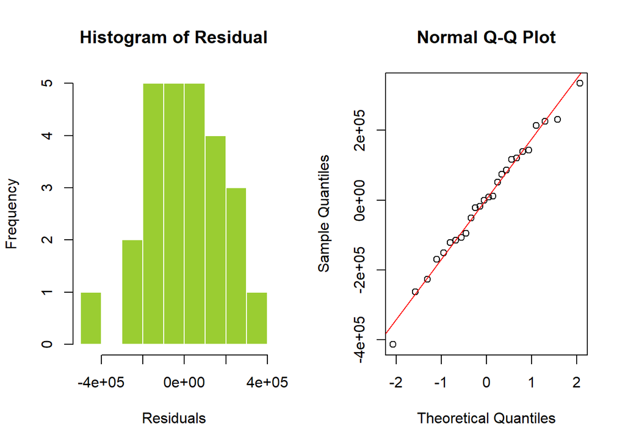

```r
par(mfrow = c(1, 2))
#Histogram of residuals
hist(res, border = 'white', col = 'olivedrab3',
     main = 'Histogram of Residual', xlab = 'Residuals')
#QQ plot
qqnorm(res)
qqline(res, col = 'red')
```